# Diversidad de gráficas al explorar datos

A lo largo del curso aprendimos a usar diferentes tipos de herramientas; desde gráficas hasta estadísticos.

Pero la relación entre ambas es que precisamente al observar las relaciones o comportamientos de las variables, analizamos si los estadísticos estaban dando una explicación adecuada. Y esto nos ayudaba a poder tener un mejor entendimiento, por esto veremos como elegir una buena gráfica.

Necesitamos preguntarnos:

- ¿Que quiero mostrar?
- ¿Que explorar?
- ¿Me gustaría mostrar una comparación?
- ¿Me gustaría mostrar una distribución?
- ¿Me gustaría mostrar una relación?
- o tal vez ¿me gustaría mostrar una composición?

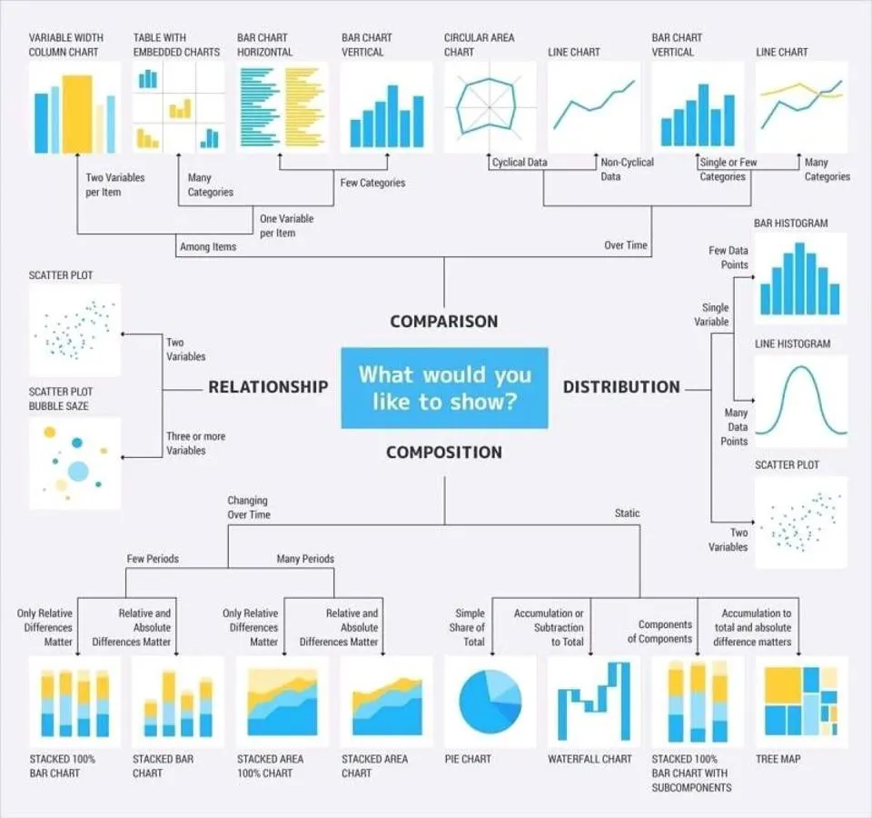

Entonces dependiendo de las respuestas a nuestras preguntas, podemos escoger diferentes gráficas. Por ejemplo:

- Distribución: Histograma, diagrama de linea o una función de probabilidad de densidad.
- Relación: Scatterplot,lmplot, calcular una matriz de correlación, clustermap, heatmap, calcular una regresión lineal. Así podemos sacar mayor provecho de una sola gráfica. Después podemos hacer segmentaciones por categorías.
- Tendencias: Gráficas de linea.
- Métricas conjuntas: Gráfica circular.
- Otro tipo de gráficas.

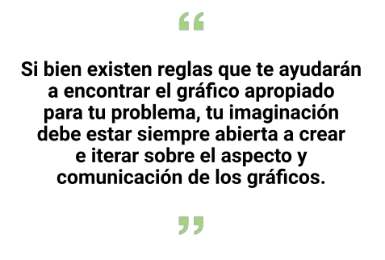

También:

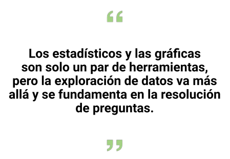